# Lab 4

Jakub Domasik

29/10/2019

# 1. Download and import data from Gapminder

The Gapminder website has a list of 519 social indicators collected. In this task, I will investigate the **Child mortality**( *0-5 years-olds dying per 1000 born* ) Libraries rio, dplyr and knitr will be required.

```r
library(rio)
library(dplyr)
library(knitr)
library(ggplot2)
Child_Data <- import("child_mortality.xlsx", setclass = "tibble")
```

```r
MyData <- Child_Data[,c(1,120:220)]
dim(MyData)
```

```
## [1] 193 102
```

```r
sum(is.na(MyData))
```

```
## [1] 546
```

There are 546 missing values in our table.

We’d like to look at our data to examine a couple of first rows.

```r
head(MyData)
```

```
## # A tibble: 6 x 102
##   country `1918` `1919` `1920` `1921` `1922` `1923` `1924` `1925` `1926`
##   <chr>    <dbl>  <dbl>  <dbl>  <dbl>  <dbl>  <dbl>  <dbl>  <dbl>  <dbl>
## 1 Afghan~    468    467    466    465    463    462    463    461    460
## 2 Albania    362    361    360    359    358    357    356    355    355
## 3 Algeria    443    442    441    440    439    438    433    429    426
## 4 Andorra     NA     NA     NA     NA     NA     NA     NA     NA     NA
## 5 Angola     468    467    466    465    463    462    461    460    459
## 6 Antigu~    182    180    179    177    176    174    173    172    170
## # ... with 92 more variables: `1927` <dbl>, `1928` <dbl>, `1929` <dbl>,
## #   `1930` <dbl>, `1931` <dbl>, `1932` <dbl>, `1933` <dbl>, `1934` <dbl>,
## #   `1935` <dbl>, `1936` <dbl>, `1937` <dbl>, `1938` <dbl>, `1939` <dbl>,
## #   `1940` <dbl>, `1941` <dbl>, `1942` <dbl>, `1943` <dbl>, `1944` <dbl>,
## #   `1945` <dbl>, `1946` <dbl>, `1947` <dbl>, `1948` <dbl>, `1949` <dbl>,
## #   `1950` <dbl>, `1951` <dbl>, `1952` <dbl>, `1953` <dbl>, `1954` <dbl>,
## #   `1955` <dbl>, `1956` <dbl>, `1957` <dbl>, `1958` <dbl>, `1959` <dbl>,
## #   `1960` <dbl>, `1961` <dbl>, `1962` <dbl>, `1963` <dbl>, `1964` <dbl>,
## #   `1965` <dbl>, `1966` <dbl>, `1967` <dbl>, `1968` <dbl>, `1969` <dbl>,
## #   `1970` <dbl>, `1971` <dbl>, `1972` <dbl>, `1973` <dbl>, `1974` <dbl>,
## #   `1975` <dbl>, `1976` <dbl>, `1977` <dbl>, `1978` <dbl>, `1979` <dbl>,
## #   `1980` <dbl>, `1981` <dbl>, `1982` <dbl>, `1983` <dbl>, `1984` <dbl>,
## #   `1985` <dbl>, `1986` <dbl>, `1987` <dbl>, `1988` <dbl>, `1989` <dbl>,
## #   `1990` <dbl>, `1991` <dbl>, `1992` <dbl>, `1993` <dbl>, `1994` <dbl>,
## #   `1995` <dbl>, `1996` <dbl>, `1997` <dbl>, `1998` <dbl>, `1999` <dbl>,
## #   `2000` <dbl>, `2001` <dbl>, `2002` <dbl>, `2003` <dbl>, `2004` <dbl>,
## #   `2005` <dbl>, `2006` <dbl>, `2007` <dbl>, `2008` <dbl>, `2009` <dbl>,
## #   `2010` <dbl>, `2011` <dbl>, `2012` <dbl>, `2013` <dbl>, `2014` <dbl>,
## #   `2015` <dbl>, `2016` <dbl>, `2017` <dbl>, `2018` <dbl>
```

# 2. Tidying the data

Then, I add the column which specifies which continent the country is part of, using the file *Countries.xlsx*. Now, as I do not want to have any missing values in the dataset, I delete it.  
In the end, I will check how many countries from each continent are in the current dataset and how many of them are in total.

```r
library(tidyr)

MyData <- gather(MyData, key = 'year', value = 'mortality', -country)

MyData <- MyData %>%
  mutate(country = factor(country), year = as.numeric(year)) %>%
  arrange(country)
Countries <- import("Countries.xlsx", setclass = "tibble")
Countries <- filter(Countries, country %in% MyData$country)

MyData <- left_join(MyData, Countries, by = "country")
MyData <- mutate(MyData, country = factor(country), continent = factor(continent))
MyData <- MyData[complete.cases(MyData),]
length(unique(MyData$country))
```

```
## [1] 175
```

```r
kable(t(as.matrix(summary(filter(MyData, year == 2005)$continent))),
      align = c('r', 'r', 'r', 'r', 'r'))
```

| Africa | Asia | Europe | North America | Oceania | South America |
| --- | --- | --- | --- | --- | --- |
| 51 | 37 | 42 | 20 | 13 | 12 |

After deleting issing values, we see that *Child Mortality* was measured each year the during last 100 years in 175 countries around the world. In the dataset, there is a fair representation of countries from every 6 inhabited continents.

# 3. Data exploration

I want to compare changes in child mortality in Europe and Asia across the last 100 years. Asia was a much less developed region 100 years ago and made enormous progress especially in the last 40 years. Child Mortality is closely related to the wealth of the country because the hygiene and quality of healthcare play a very important role here.

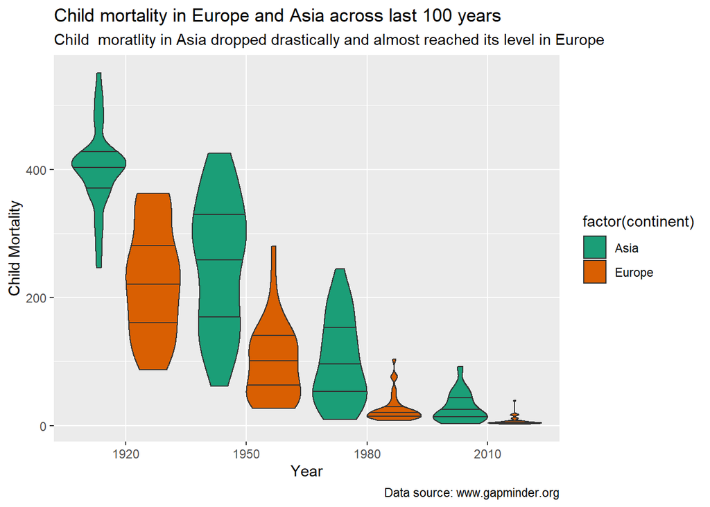

```r
SubData <- filter(MyData, year %in% c(1920 ,1950, 1980, 2010) & continent %in%  c("Europe", "Asia"))

ggplot(SubData, aes(x = factor(year), y = mortality, fill = factor(continent))) +
 geom_violin(scale = "width", draw_quantiles = c(0.25, 0.5, 0.75)) +
  labs( x = "Year", y = "Child Mortality", title = "Child mortality in Europe and Asia across last 100 years", subtitle = "Child  moratlity in Asia dropped drastically and almost reached its level in Europe",
        caption = "Data source: www.gapminder.org") +
  scale_fill_brewer(palette="Dark2")
```

The graph shows that Child Mortality was very high in 1920 on both continents. However, in Asia more than 400 out of 1000 children had been dying before $5^{th}$ birthday on average, while in Europe this number was almost two times smaller. Despite the constant decrease in Asia, it was only during the period 1980 - 2010 when Asia caught up to Europe. We may conclude that this is the case because of rapid economic growth in so-called “Asian tigers”, China and India. Our graph does not account for the population of each country so the impact of China and India on this decrease is the same as every other Asian country.

Concluding, I may say that Asia has been very successfully fighting Child Mortality in the last 100 years and is finally reaching its level in Europe. However, there is still a gap between them. The Asian violin from 2010 is very similar to the European one from 1980. It has only the slightly thicker upper tail. This means that Asia while making huge progress, is still around 30 years behind Europe in terms of Child Mortality.

To further examine the relationship between wealth and child mortality, I will present the second graph.

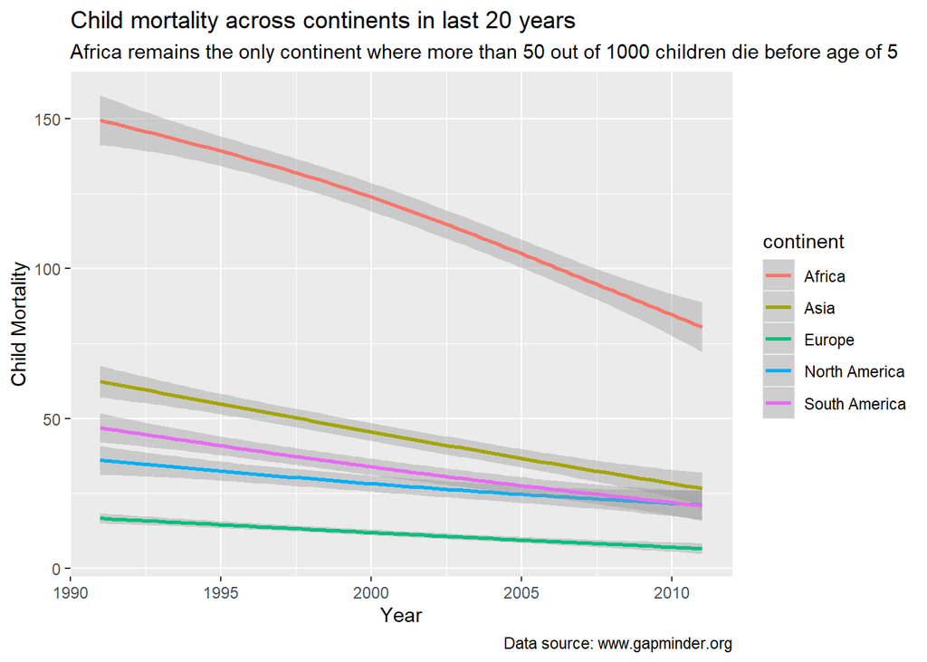

```r
MyData1 <- filter(MyData, (continent == "Europe" | continent == "Asia" |
                                  continent == "Africa" | continent == "South America" |
                                  continent == "North America") & (year %in% c(1991:2011)))
ggplot(MyData1, aes(x = year, y = mortality, color=continent))+
  geom_smooth()+labs(x = "Year", y = "Child Mortality",
                     title = "Child mortality across continents in last 20 years",
                     caption = "Data source: www.gapminder.org", subtitle = "Africa remains the only continent where more than 50 out of 1000 children die before age of 5")
```

Concluding, while in most of the world Child Mortality is not a problem anymore, Africa is still fighting with it and many children are dying because of the lack of hygiene, noutritious food and basic medicine. Africa made huge progress in the last 20 years reducing the percent of children dying before the age of 5 by almost 50% which is still couple of times more than in Asia, America or Europe.